# Report on tr3 phenotypes + weight/height tests

Andrey Ziyatdinov

2015-10-20

# About

Motivation: explore different model building strategies for covariate selection.

Main points:

- Employ bayesian model averaging (implemented in SOLAR, See [tutorial](http://helix.nih.gov/Documentation/solar-6.6.2-doc/06.chapter.html), Section 6.6.2 Bayesian Model Averaging with Covariates) for covariate selection.
  - Fix “secure” covariates: `Age` and `Sex`, when it is the case.
- Pre-process `Age` covariate by both centering and scaling (named as `Agesc`, where `sc` means scaled).
- Mantain two protocols: with & without `Height` and `Weight` covariates.

## Models

1. Model protocol as in the last paper submission, i.e. all covariates are put into the base model and then screening is applied.
2. Bayesian model averaging + `Age` and `Sex` fixed.
3. Bayesian model averaging + `Age` and `Sex` fixed + Weight + Height.

Note that Models 1 and 2 does not include `Height` and `Weight` covariates.

(Andrey’s opinion) Models 2 is the way to go.

## Data cleanining

See report 01-phen.html.

- Several outlier observations were removed.
- Trait transformation were re-defined (now `tr3_` prefix is used for trait names).

# Covariates ~ model

The table below shows a list of covariates per trait according to one of the modeling strategies, indexed as 1, 2 and 3.

| trait | covlist | model |
| --- | --- | --- |
| tr3_AxisLen | Agesc, Agesc2, Sexf | 1 |
|  | Agesc, Agesc2, Sexf | 2 |
|  | Agesc, Agesc2, Sexf, Height | 3 |
| tr3_FemShACT | Agesc, Agesc2, Sexf | 1 |
|  | Agesc, Agesc2, Sexf | 2 |
|  | Agesc, Agesc2, Sexf, Height, Weight | 3 |
| tr3_FemShBR | Agesc, Agesc2 | 1 |
|  | Agesc, Agesc2 | 2 |
|  | Agesc, Agesc2, Weight | 3 |
| tr3_FemShCSA | Agesc, Agesc2, Sexf, Alcohol | 1 |
|  | Agesc, Agesc2, Sexf | 2 |
|  | Agesc, Agesc2, Sexf, Height, Weight | 3 |
| tr3_FemShCSMI | Agesc, Agesc2, Sexf | 1 |
|  | Agesc, Agesc2, Sexf | 2 |
|  | Agesc, Agesc2, Sexf, Height, Weight | 3 |
| tr3_FemShSMod | Agesc, Agesc2, Sexf | 1 |
|  | Agesc, Agesc2, Sexf | 2 |
|  | Agesc, Agesc2, Sexf, Height, Weight | 3 |
| tr3_HipTotBMD | Agesc, Agesc2, Sexf | 1 |
|  | Agesc, Agesc2, Sexf | 2 |
|  | Agesc, Agesc2, Sexf, Height, Weight | 3 |
| tr3_InterBMD | Agesc, Agesc2, Sexf | 1 |
|  | Agesc, Agesc2, Sexf | 2 |
|  | Agesc, Agesc2, Sexf, Height, Weight | 3 |
| tr3_IntTrACT | Agesc, Agesc2, Sexf | 1 |
|  | Agesc, Agesc2, Sexf | 2 |
|  | Agesc, Agesc2, Sexf, Height, Weight | 3 |
| tr3_IntTrBR | Agesc | 1 |
|  | Agesc | 2 |
|  | Agesc | 3 |

[output cut: 96 more lines]

# h2r ~ model

3 x `42` polygenic models were computed in total.

The first figure shows how different is estimation of `h2r` depending on model 1, 2 or 3.

The second figure shows results for those models, where `Height` and/or `Weight` covariates appeared to be included in model 3.

The third figure shows results for those models, where both `Height` and `Weight` covariates appeared to be included in model 3.

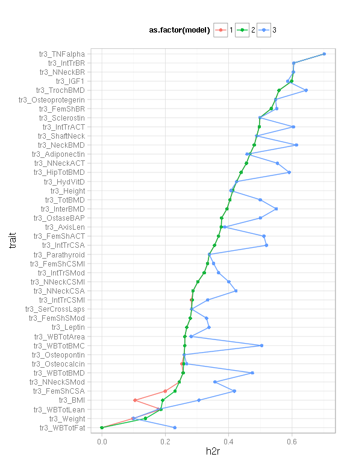

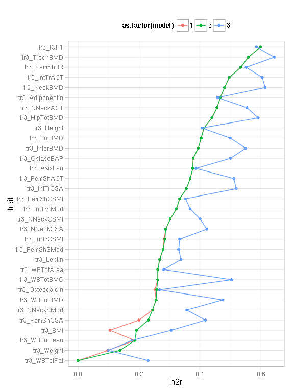

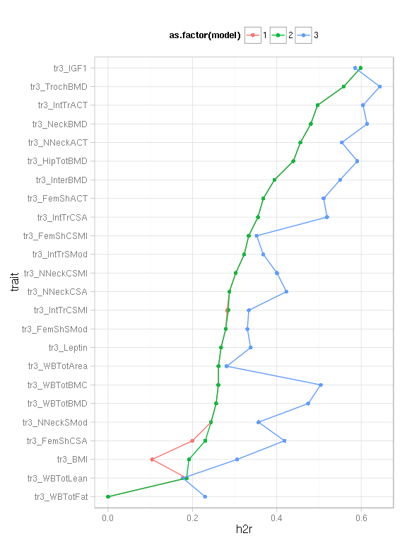

It is likely to be suggested that the model of `tr3_WBTotFat` trait to be discarded from the study. The basic univariate polygenic model has very low `h2r`, and it could cause problems in furher bivariate studies.

# Correlations (model 2)

In this section results are presented for analysis according to model 2. If it is not especially noted, the default threshold significant level `0.0013889` (`0.05 / 36`) is used.

The tables below show only significant correlations. The rows are ordered. The first column named `rank` show the order according to either `pvalp`, `pvale` or `pvalg` value.

## Significant phenotipic

| rank | traits | rhog | rhoe | pvalg | pvale | rhop | pvalp |
| --- | --- | --- | --- | --- | --- | --- | --- |
| 1 | tr3_WBTotFat_tr3_Leptin | 0.8764 | 0.7805 | 0.5311 | 7.971e-17 | 0.7195 | 1.433e-61 |
| 2 | tr3_WBTotBMD_tr3_OstaseBAP | -0.07004 | -0.5141 | 0.7102 | 4.51e-10 | -0.3649 | 4.757e-11 |
| 3 | tr3_IntTrSMod_tr3_IGF1 | 0.4076 | 0.2273 | 0.01827 | 0.04422 | 0.2983 | 2.642e-09 |
| 4 | tr3_FemShACT_tr3_SerCrossLaps | -0.07915 | -0.4435 | 0.6999 | 3.746e-07 | -0.323 | 7.606e-09 |
| 5 | tr3_IntTrCSMI_tr3_IGF1 | 0.3628 | 0.223 | 0.04074 | 0.03936 | 0.2709 | 1.114e-08 |
| 6 | tr3_WBTotBMC_tr3_OstaseBAP | 0.03808 | -0.4966 | 0.8356 | 3.102e-09 | -0.3124 | 2.188e-08 |
| 7 | tr3_TotBMD_tr3_OstaseBAP | -0.1556 | -0.4129 | 0.3534 | 7.795e-06 | -0.3088 | 4.728e-08 |
| 8 | tr3_WBTotBMD_tr3_SerCrossLaps | -0.227 | -0.3182 | 0.3145 | 9.77e-05 | -0.2934 | 6.043e-08 |
| 9 | tr3_AxisLen_tr3_IGF1 | 0.2191 | 0.2811 | 0.1051 | 0.00909 | 0.2446 | 8.041e-08 |
| 10 | tr3_FemShACT_tr3_OstaseBAP | -0.05524 | -0.4275 | 0.7473 | 1.714e-06 | -0.2854 | 3.769e-07 |
| 11 | tr3_IntTrCSA_tr3_IGF1 | 0.3982 | 0.1744 | 0.01492 | 0.1246 | 0.2733 | 8.858e-07 |
| 12 | tr3_WBTotBMC_tr3_SerCrossLaps | -0.1581 | -0.293 | 0.4788 | 0.0004194 | -0.2557 | 2.777e-06 |
| 13 | tr3_WBTotLean_tr3_IGF1 | 0.3345 | 0.2649 | 0.1191 | 0.01476 | 0.2644 | 3.155e-06 |
| 14 | tr3_FemShCSA_tr3_SerCrossLaps | -0.01788 | -0.3379 | 0.9402 | 4.92e-05 | -0.2535 | 3.889e-06 |
| 15 | tr3_FemShBR_tr3_SerCrossLaps | 0.1393 | 0.3507 | 0.4389 | 0.0003004 | 0.256 | 4.712e-06 |
| 16 | tr3_NNeckCSMI_tr3_IGF1 | 0.208 | 0.2342 | 0.2431 | 0.03251 | 0.2129 | 5.474e-06 |
| 17 | tr3_NNeckCSA_tr3_IGF1 | 0.2902 | 0.1799 | 0.1099 | 0.1061 | 0.2174 | 5.632e-06 |
| 18 | tr3_NNeckCSA_tr3_OstaseBAP | -0.05652 | -0.3514 | 0.7673 | 4.8e-05 | -0.2513 | 6.059e-06 |
| 19 | tr3_InterBMD_tr3_OstaseBAP | -0.03232 | -0.3935 | 0.8534 | 1.91e-05 | -0.2527 | 6.732e-06 |
| 20 | tr3_FemShCSA_tr3_OstaseBAP | 0.07124 | -0.3993 | 0.7227 | 2.416e-06 | -0.2494 | 6.944e-06 |
| 21 | tr3_WBTotArea_tr3_IGF1 | 0.2446 | 0.2748 | 0.1777 | 0.007524 | 0.2469 | 7.761e-06 |
| 22 | tr3_HipTotBMD_tr3_OstaseBAP | -0.1095 | -0.3481 | 0.5176 | 0.0002317 | -0.2499 | 8.404e-06 |
| 23 | tr3_TotBMD_tr3_SerCrossLaps | -0.1965 | -0.2735 | 0.3285 | 0.002839 | -0.2445 | 1.21e-05 |
| 24 | tr3_InterBMD_tr3_SerCrossLaps | 0.02969 | -0.3924 | 0.8858 | 1.56e-05 | -0.2464 | 1.25e-05 |
| 25 | tr3_HipTotBMD_tr3_SerCrossLaps | -0.027 | -0.3772 | 0.8922 | 5.31e-05 | -0.2467 | 1.32e-05 |
| 26 | tr3_NNeckACT_tr3_OstaseBAP | -0.1529 | -0.3115 | 0.3669 | 0.001122 | -0.245 | 1.33e-05 |
| 27 | tr3_WBTotBMD_tr3_Osteocalcin | 0.4035 | -0.4863 | 0.101 | 2.352e-08 | -0.2417 | 1.5e-05 |
| 28 | tr3_NeckBMD_tr3_OstaseBAP | -0.1251 | -0.3376 | 0.4491 | 0.0005444 | -0.2444 | 1.67e-05 |
| 29 | tr3_WBTotArea_tr3_OstaseBAP | 0.204 | -0.476 | 0.2605 | 2.099e-08 | -0.2385 | 2e-05 |
| 30 | tr3_WBTotBMC_tr3_IGF1 | 0.2237 | 0.168 | 0.1631 | 0.106 | 0.1803 | 2.55e-05 |
| 31 | tr3_NNeckSMod_tr3_IGF1 | 0.273 | 0.226 | 0.1547 | 0.0343 | 0.2299 | 2.93e-05 |
| 32 | tr3_TrochBMD_tr3_IGF1 | 0.3437 | 0.09435 | 0.02063 | 0.4967 | 0.2377 | 5.19e-05 |
| 33 | tr3_WBTotArea_tr3_SerCrossLaps | -0.08349 | -0.2753 | 0.7059 | 0.001039 | -0.2215 | 5.2e-05 |
| 34 | tr3_IntTrACT_tr3_IGF1 | 0.3568 | 0.08283 | 0.01425 | 0.5064 | 0.2319 | 5.32e-05 |
| 35 | tr3_FemShBR_tr3_OstaseBAP | 0.1901 | 0.2628 | 0.2153 | 0.00832 | 0.2269 | 6.2e-05 |
| 36 | tr3_NNeckSMod_tr3_OstaseBAP | 0.01909 | -0.3369 | 0.9227 | 7.53e-05 | -0.2215 | 6.23e-05 |
| 37 | tr3_WBTotBMD_tr3_IGF1 | 0.2468 | 0.1723 | 0.1803 | 0.09903 | 0.1911 | 8.02e-05 |
| 38 | tr3_WBTotBMC_tr3_Osteocalcin | 0.3798 | -0.4738 | 0.09967 | 9.278e-08 | -0.222 | 8.47e-05 |
| 39 | tr3_WBTotBMC_tr3_Sclerostin | 0.3909 | 0.1133 | 0.03572 | 0.2474 | 0.2143 | 9.88e-05 |
| 40 | tr3_TotBMD_tr3_Osteocalcin | 0.2532 | -0.4723 | 0.2389 | 9.168e-07 | -0.2173 | 0.0001348 |
| 41 | tr3_NNeckCSA_tr3_SerCrossLaps | -0.02128 | -0.2833 | 0.9236 | 0.0009253 | -0.2076 | 0.0001709 |
| 42 | tr3_HipTotBMD_tr3_IGF1 | 0.2925 | 0.06576 | 0.0633 | 0.5944 | 0.1813 | 0.000196 |
| 43 | tr3_FemShACT_tr3_Osteocalcin | 0.2087 | -0.3721 | 0.3846 | 4.49e-05 | -0.1972 | 0.0003365 |
| 44 | tr3_NNeckACT_tr3_SerCrossLaps | -0.04056 | -0.2976 | 0.8366 | 0.0016 | -0.201 | 0.0003611 |
| 45 | tr3_TotBMD_tr3_Sclerostin | 0.2085 | 0.2005 | 0.2294 | 0.0657 | 0.2032 | 0.0003649 |
| 46 | tr3_WBTotArea_tr3_Osteocalcin | 0.2667 | -0.393 | 0.252 | 1.02e-05 | -0.1998 | 0.0003828 |
| 47 | tr3_IntTrACT_tr3_SerCrossLaps | -0.03165 | -0.3056 | 0.8647 | 0.001284 | -0.1958 | 0.000488 |
| 48 | tr3_NeckBMD_tr3_SerCrossLaps | -0.04265 | -0.2987 | 0.8249 | 0.001863 | -0.1973 | 0.0004971 |
| 49 | tr3_NNeckCSMI_tr3_OstaseBAP | 0.04246 | -0.3264 | 0.8139 | 0.0002546 | -0.1936 | 0.0005729 |
| 50 | tr3_TrochBMD_tr3_Sclerostin | 0.3279 | 0.05623 | 0.03407 | 0.6526 | 0.2004 | 0.0005856 |
| 51 | tr3_FemShSMod_tr3_OstaseBAP | 0.09077 | -0.3376 | 0.6261 | 0.0001088 | -0.1904 | 0.0006316 |
| 52 | tr3_WBTotBMD_tr3_Sclerostin | 0.4019 | 0.06212 | 0.03112 | 0.5302 | 0.1876 | 0.0006586 |
| 53 | tr3_NNeckSMod_tr3_SerCrossLaps | 0.00823 | -0.259 | 0.9716 | 0.002086 | -0.1868 | 0.0006694 |
| 54 | tr3_WBTotLean_tr3_SerCrossLaps | -0.02346 | -0.2337 | 0.9275 | 0.0058 | -0.1824 | 0.0008609 |
| 55 | tr3_HipTotBMD_tr3_Sclerostin | 0.3577 | 0.03613 | 0.02864 | 0.7497 | 0.1889 | 0.0008618 |
| 56 | tr3_IntTrSMod_tr3_Sclerostin | 0.3202 | 0.09244 | 0.08089 | 0.3783 | 0.1831 | 0.001036 |
| 57 | tr3_InterBMD_tr3_IGF1 | 0.3037 | 0.05079 | 0.06231 | 0.6727 | 0.1733 | 0.001138 |
| 58 | tr3_IntTrACT_tr3_Sclerostin | 0.3952 | -0.02626 | 0.009436 | 0.8171 | 0.184 | 0.001203 |
| 59 | tr3_NeckBMD_tr3_IGF1 | 0.2233 | 0.08016 | 0.1465 | 0.5309 | 0.1565 | 0.001236 |
| 60 | tr3_IntTrCSA_tr3_OstaseBAP | 0.0231 | -0.2978 | 0.8961 | 0.0008685 | -0.1791 | 0.00132 |
| 61 | tr3_TrochBMD_tr3_OstaseBAP | -0.2235 | -0.1489 | 0.1593 | 0.1578 | -0.181 | 0.001361 |

## Significant environmental

| rank | traits | rhog | rhoe | pvalg | pvale | rhop | pvalp |
| --- | --- | --- | --- | --- | --- | --- | --- |
| 1 | tr3_WBTotFat_tr3_Leptin | 0.8764 | 0.7805 | 0.5311 | 7.971e-17 | 0.7195 | 1.433e-61 |
| 2 | tr3_WBTotBMD_tr3_OstaseBAP | -0.07004 | -0.5141 | 0.7102 | 4.51e-10 | -0.3649 | 4.757e-11 |
| 3 | tr3_WBTotBMC_tr3_OstaseBAP | 0.03808 | -0.4966 | 0.8356 | 3.102e-09 | -0.3124 | 2.188e-08 |
| 4 | tr3_WBTotArea_tr3_OstaseBAP | 0.204 | -0.476 | 0.2605 | 2.099e-08 | -0.2385 | 2e-05 |
| 5 | tr3_WBTotBMD_tr3_Osteocalcin | 0.4035 | -0.4863 | 0.101 | 2.352e-08 | -0.2417 | 1.5e-05 |
| 6 | tr3_WBTotBMC_tr3_Osteocalcin | 0.3798 | -0.4738 | 0.09967 | 9.278e-08 | -0.222 | 8.47e-05 |
| 7 | tr3_FemShACT_tr3_SerCrossLaps | -0.07915 | -0.4435 | 0.6999 | 3.746e-07 | -0.323 | 7.606e-09 |
| 8 | tr3_TotBMD_tr3_Osteocalcin | 0.2532 | -0.4723 | 0.2389 | 9.168e-07 | -0.2173 | 0.0001348 |
| 9 | tr3_WBTotLean_tr3_OstaseBAP | 0.3693 | -0.4298 | 0.07833 | 1.016e-06 | -0.1824 | 0.00155 |
| 10 | tr3_FemShACT_tr3_OstaseBAP | -0.05524 | -0.4275 | 0.7473 | 1.714e-06 | -0.2854 | 3.769e-07 |
| 11 | tr3_FemShCSA_tr3_OstaseBAP | 0.07124 | -0.3993 | 0.7227 | 2.416e-06 | -0.2494 | 6.944e-06 |
| 12 | tr3_TotBMD_tr3_OstaseBAP | -0.1556 | -0.4129 | 0.3534 | 7.795e-06 | -0.3088 | 4.728e-08 |
| 13 | tr3_AxisLen_tr3_OstaseBAP | 0.3201 | -0.3983 | 0.04622 | 1.02e-05 | -0.1109 | 0.04841 |
| 14 | tr3_WBTotArea_tr3_Osteocalcin | 0.2667 | -0.393 | 0.252 | 1.02e-05 | -0.1998 | 0.0003828 |
| 15 | tr3_NNeckCSA_tr3_Osteocalcin | 0.4313 | -0.3991 | 0.07176 | 1.28e-05 | -0.1524 | 0.006983 |
| 16 | tr3_FemShCSA_tr3_Osteocalcin | 0.3817 | -0.3785 | 0.1366 | 1.52e-05 | -0.1775 | 0.001391 |
| 17 | tr3_InterBMD_tr3_Osteocalcin | 0.3132 | -0.4118 | 0.1786 | 1.53e-05 | -0.1754 | 0.001826 |
| 18 | tr3_InterBMD_tr3_SerCrossLaps | 0.02969 | -0.3924 | 0.8858 | 1.56e-05 | -0.2464 | 1.25e-05 |
| 19 | tr3_InterBMD_tr3_OstaseBAP | -0.03232 | -0.3935 | 0.8534 | 1.91e-05 | -0.2527 | 6.732e-06 |
| 20 | tr3_NNeckSMod_tr3_Osteocalcin | 0.5037 | -0.3667 | 0.04135 | 3.92e-05 | -0.1249 | 0.02549 |
| 21 | tr3_HipTotBMD_tr3_Osteocalcin | 0.2557 | -0.4029 | 0.2553 | 4e-05 | -0.1734 | 0.002124 |
| 22 | tr3_FemShACT_tr3_Osteocalcin | 0.2087 | -0.3721 | 0.3846 | 4.49e-05 | -0.1972 | 0.0003365 |
| 23 | tr3_NNeckCSA_tr3_OstaseBAP | -0.05652 | -0.3514 | 0.7673 | 4.8e-05 | -0.2513 | 6.059e-06 |
| 24 | tr3_FemShCSA_tr3_SerCrossLaps | -0.01788 | -0.3379 | 0.9402 | 4.92e-05 | -0.2535 | 3.889e-06 |
| 25 | tr3_HipTotBMD_tr3_SerCrossLaps | -0.027 | -0.3772 | 0.8922 | 5.31e-05 | -0.2467 | 1.32e-05 |
| 26 | tr3_NNeckSMod_tr3_OstaseBAP | 0.01909 | -0.3369 | 0.9227 | 7.53e-05 | -0.2215 | 6.23e-05 |
| 27 | tr3_NNeckCSMI_tr3_Osteocalcin | 0.502 | -0.3694 | 0.02429 | 8.45e-05 | -0.09181 | 0.1047 |
| 28 | tr3_WBTotBMD_tr3_SerCrossLaps | -0.227 | -0.3182 | 0.3145 | 9.77e-05 | -0.2934 | 6.043e-08 |
| 29 | tr3_FemShSMod_tr3_OstaseBAP | 0.09077 | -0.3376 | 0.6261 | 0.0001088 | -0.1904 | 0.0006316 |
| 30 | tr3_FemShCSMI_tr3_OstaseBAP | 0.1581 | -0.3401 | 0.3647 | 0.0001425 | -0.1549 | 0.005773 |
| 31 | tr3_FemShSMod_tr3_Osteocalcin | 0.2966 | -0.3394 | 0.1957 | 0.0002288 | -0.1464 | 0.009209 |
| 32 | tr3_HipTotBMD_tr3_OstaseBAP | -0.1095 | -0.3481 | 0.5176 | 0.0002317 | -0.2499 | 8.404e-06 |
| 33 | tr3_NNeckCSMI_tr3_OstaseBAP | 0.04246 | -0.3264 | 0.8139 | 0.0002546 | -0.1936 | 0.0005729 |
| 34 | tr3_NNeckACT_tr3_Osteocalcin | 0.2076 | -0.3649 | 0.3459 | 0.0002734 | -0.1579 | 0.005282 |
| 35 | tr3_FemShBR_tr3_SerCrossLaps | 0.1393 | 0.3507 | 0.4389 | 0.0003004 | 0.256 | 4.712e-06 |
| 36 | tr3_NeckBMD_tr3_Osteocalcin | 0.2587 | -0.3682 | 0.2231 | 0.0003324 | -0.1307 | 0.02182 |
| 37 | tr3_WBTotBMC_tr3_SerCrossLaps | -0.1581 | -0.293 | 0.4788 | 0.0004194 | -0.2557 | 2.777e-06 |
| 38 | tr3_FemShCSMI_tr3_Osteocalcin | 0.279 | -0.3316 | 0.1932 | 0.0004618 | -0.1294 | 0.0219 |
| 39 | tr3_NeckBMD_tr3_OstaseBAP | -0.1251 | -0.3376 | 0.4491 | 0.0005444 | -0.2444 | 1.67e-05 |
| 40 | tr3_IntTrCSA_tr3_OstaseBAP | 0.0231 | -0.2978 | 0.8961 | 0.0008685 | -0.1791 | 0.00132 |
| 41 | tr3_NNeckCSA_tr3_SerCrossLaps | -0.02128 | -0.2833 | 0.9236 | 0.0009253 | -0.2076 | 0.0001709 |
| 42 | tr3_WBTotArea_tr3_SerCrossLaps | -0.08349 | -0.2753 | 0.7059 | 0.001039 | -0.2215 | 5.2e-05 |
| 43 | tr3_WBTotLean_tr3_Osteocalcin | 0.2165 | -0.3031 | 0.4701 | 0.001082 | -0.1723 | 0.002566 |
| 44 | tr3_NNeckACT_tr3_OstaseBAP | -0.1529 | -0.3115 | 0.3669 | 0.001122 | -0.245 | 1.33e-05 |
| 45 | tr3_IntTrACT_tr3_SerCrossLaps | -0.03165 | -0.3056 | 0.8647 | 0.001284 | -0.1958 | 0.000488 |

## Significant genetic

There are no models that passed multiple-correction procedure.

### Threshold 0.05 / 12

| rank | traits | rhog | rhoe | pvalg | pvale | rhop | pvalp |
| --- | --- | --- | --- | --- | --- | --- | --- |
| 1 | tr3_IntTrBR_tr3_Sclerostin | -0.4219 | 0.1391 | 0.002642 | 0.2603 | -0.1735 | 0.002694 |

### Threshold 0.05 / 3

| rank | traits | rhog | rhoe | pvalg | pvale | rhop | pvalp |
| --- | --- | --- | --- | --- | --- | --- | --- |
| 1 | tr3_IntTrBR_tr3_Sclerostin | -0.4219 | 0.1391 | 0.002642 | 0.2603 | -0.1735 | 0.002694 |
| 2 | tr3_NeckBMD_tr3_Leptin | 0.587 | -0.1851 | 0.004788 | 0.08516 | 0.1068 | 0.05628 |
| 3 | tr3_IntTrBR_tr3_HydVitD | -0.3913 | 0.08269 | 0.007429 | 0.4597 | -0.1571 | 0.006293 |
| 4 | tr3_IntTrACT_tr3_Sclerostin | 0.3952 | -0.02626 | 0.009436 | 0.8171 | 0.184 | 0.001203 |
| 5 | tr3_ShaftNeck_tr3_TNFalpha | 0.3575 | -0.2922 | 0.01085 | 0.02708 | 0.08258 | 0.1452 |
| 6 | tr3_NNeckCSA_tr3_Leptin | 0.593 | -0.1267 | 0.01249 | 0.1788 | 0.08614 | 0.1186 |
| 7 | tr3_NNeckSMod_tr3_Leptin | 0.6225 | -0.1857 | 0.01375 | 0.04133 | 0.03299 | 0.5505 |
| 8 | tr3_IntTrACT_tr3_IGF1 | 0.3568 | 0.08283 | 0.01425 | 0.5064 | 0.2319 | 5.32e-05 |
| 9 | tr3_IntTrCSA_tr3_IGF1 | 0.3982 | 0.1744 | 0.01492 | 0.1246 | 0.2733 | 8.858e-07 |

# Correlations (model 3)

In this section results are presented for analysis according to model 3. If it is not especially noted, the default threshold significant level `0.0013889` (`0.05 / 36`) is used.

## Significant phenotipic

| rank | traits | rhog | rhoe | pvalg | pvale | rhop | pvalp |
| --- | --- | --- | --- | --- | --- | --- | --- |
| 1 | tr3_WBTotFat_tr3_Leptin | 0.5158 | 0.6937 | 0.04162 | 3.361e-12 | 0.6379 | 7.627e-33 |
| 2 | tr3_WBTotLean_tr3_Leptin | -0.2973 | -0.5493 | 0.2582 | 1.298e-08 | -0.4732 | 1.07e-16 |
| 3 | tr3_WBTotBMD_tr3_OstaseBAP | -0.3109 | -0.2949 | 0.04054 | 0.006552 | -0.3026 | 7.586e-08 |
| 4 | tr3_FemShACT_tr3_SerCrossLaps | -0.0685 | -0.4337 | 0.7119 | 5.064e-06 | -0.2861 | 4.512e-07 |
| 5 | tr3_FemShBR_tr3_SerCrossLaps | 0.125 | 0.3564 | 0.4807 | 0.0002601 | 0.251 | 7.027e-06 |
| 6 | tr3_FemShSMod_tr3_Leptin | 0.04115 | -0.3901 | 0.8588 | 6.08e-05 | -0.2482 | 8.867e-06 |
| 7 | tr3_FemShCSMI_tr3_Leptin | -0.04725 | -0.3501 | 0.8288 | 0.0003749 | -0.2455 | 1.11e-05 |
| 8 | tr3_WBTotBMC_tr3_OstaseBAP | -0.228 | -0.2653 | 0.1247 | 0.01634 | -0.2465 | 1.44e-05 |
| 9 | tr3_FemShBR_tr3_OstaseBAP | 0.2481 | 0.2462 | 0.07574 | 0.02767 | 0.247 | 1.57e-05 |
| 10 | tr3_WBTotBMC_tr3_Leptin | 0.05229 | -0.4507 | 0.7967 | 2.53e-05 | -0.2421 | 1.9e-05 |
| 11 | tr3_FemShACT_tr3_OstaseBAP | -0.1932 | -0.2926 | 0.1899 | 0.008167 | -0.2425 | 2.09e-05 |
| 12 | tr3_TotBMD_tr3_SerCrossLaps | -0.2197 | -0.2561 | 0.2551 | 0.009486 | -0.236 | 2.98e-05 |
| 13 | tr3_WBTotBMD_tr3_SerCrossLaps | -0.1714 | -0.2764 | 0.3628 | 0.003172 | -0.2343 | 3.15e-05 |
| 14 | tr3_WBTotBMC_tr3_Sclerostin | 0.4743 | -0.01508 | 0.001435 | 0.8964 | 0.2346 | 3.47e-05 |
| 15 | tr3_TotBMD_tr3_OstaseBAP | -0.3187 | -0.121 | 0.04179 | 0.2975 | -0.2178 | 0.0001453 |
| 16 | tr3_InterBMD_tr3_OstaseBAP | -0.1994 | -0.2113 | 0.1756 | 0.06939 | -0.2048 | 0.0003362 |
| 17 | tr3_HipTotBMD_tr3_OstaseBAP | -0.2624 | -0.1316 | 0.06544 | 0.2767 | -0.2023 | 0.0004073 |
| 18 | tr3_TotBMD_tr3_Sclerostin | 0.1975 | 0.215 | 0.2424 | 0.08132 | 0.2062 | 0.0004269 |
| 19 | tr3_FemShCSA_tr3_SerCrossLaps | 0.04654 | -0.3313 | 0.8132 | 0.0003129 | -0.1979 | 0.000461 |
| 20 | tr3_NNeckACT_tr3_OstaseBAP | -0.3033 | -0.0853 | 0.04216 | 0.4807 | -0.2007 | 0.000464 |
| 21 | tr3_WBTotArea_tr3_Leptin | -0.1029 | -0.2307 | 0.6669 | 0.01482 | -0.1909 | 0.0005049 |
| 22 | tr3_InterBMD_tr3_SerCrossLaps | 0.03558 | -0.3709 | 0.8496 | 0.0002301 | -0.1989 | 0.0005069 |
| 23 | tr3_HipTotBMD_tr3_SerCrossLaps | -0.02108 | -0.3505 | 0.9078 | 0.000792 | -0.1996 | 0.0005076 |
| 24 | tr3_WBTotArea_tr3_Sclerostin | 0.3006 | 0.133 | 0.1186 | 0.1854 | 0.1919 | 0.0005389 |
| 25 | tr3_NeckBMD_tr3_OstaseBAP | -0.2898 | -0.07984 | 0.04545 | 0.5278 | -0.1957 | 0.0007125 |
| 26 | tr3_WBTotBMC_tr3_SerCrossLaps | -0.09267 | -0.2602 | 0.6135 | 0.007037 | -0.1909 | 0.0007719 |

## Significant environmental

| rank | traits | rhog | rhoe | pvalg | pvale | rhop | pvalp |
| --- | --- | --- | --- | --- | --- | --- | --- |
| 1 | tr3_WBTotFat_tr3_Leptin | 0.5158 | 0.6937 | 0.04162 | 3.361e-12 | 0.6379 | 7.627e-33 |
| 2 | tr3_WBTotLean_tr3_Leptin | -0.2973 | -0.5493 | 0.2582 | 1.298e-08 | -0.4732 | 1.07e-16 |
| 3 | tr3_NNeckCSMI_tr3_Leptin | 0.5514 | -0.5417 | 0.008777 | 6.878e-08 | -0.1344 | 0.01981 |
| 4 | tr3_NNeckSMod_tr3_Leptin | 0.5724 | -0.4868 | 0.01201 | 7.967e-07 | -0.1245 | 0.0293 |
| 5 | tr3_FemShACT_tr3_SerCrossLaps | -0.0685 | -0.4337 | 0.7119 | 5.064e-06 | -0.2861 | 4.512e-07 |
| 6 | tr3_WBTotBMC_tr3_Leptin | 0.05229 | -0.4507 | 0.7967 | 2.53e-05 | -0.2421 | 1.9e-05 |
| 7 | tr3_WBTotBMC_tr3_Osteocalcin | 0.411 | -0.4286 | 0.04865 | 5.12e-05 | -0.1095 | 0.05495 |
| 8 | tr3_FemShSMod_tr3_Leptin | 0.04115 | -0.3901 | 0.8588 | 6.08e-05 | -0.2482 | 8.867e-06 |
| 9 | tr3_NNeckCSA_tr3_Leptin | 0.5369 | -0.4158 | 0.01567 | 6.08e-05 | -0.0687 | 0.2275 |
| 10 | tr3_WBTotBMD_tr3_Osteocalcin | 0.3064 | -0.405 | 0.1783 | 9.25e-05 | -0.157 | 0.005436 |
| 11 | tr3_TotBMD_tr3_Osteocalcin | 0.258 | -0.4055 | 0.2772 | 0.0001605 | -0.164 | 0.003847 |
| 12 | tr3_InterBMD_tr3_SerCrossLaps | 0.03558 | -0.3709 | 0.8496 | 0.0002301 | -0.1989 | 0.0005069 |
| 13 | tr3_FemShBR_tr3_SerCrossLaps | 0.125 | 0.3564 | 0.4807 | 0.0002601 | 0.251 | 7.027e-06 |
| 14 | tr3_FemShCSA_tr3_Leptin | 0.3363 | -0.3647 | 0.1138 | 0.0002883 | -0.1086 | 0.05441 |
| 15 | tr3_FemShCSA_tr3_SerCrossLaps | 0.04654 | -0.3313 | 0.8132 | 0.0003129 | -0.1979 | 0.000461 |
| 16 | tr3_FemShCSMI_tr3_Leptin | -0.04725 | -0.3501 | 0.8288 | 0.0003749 | -0.2455 | 1.11e-05 |
| 17 | tr3_WBTotBMD_tr3_Leptin | 0.1931 | -0.3572 | 0.363 | 0.0007086 | -0.1435 | 0.01084 |
| 18 | tr3_HipTotBMD_tr3_SerCrossLaps | -0.02108 | -0.3505 | 0.9078 | 0.000792 | -0.1996 | 0.0005076 |

## Significant genetic

There are no models that passed multiple-correction procedure.

### Threshold 0.05 / 12

| rank | traits | rhog | rhoe | pvalg | pvale | rhop | pvalp |
| --- | --- | --- | --- | --- | --- | --- | --- |
| 1 | tr3_WBTotBMC_tr3_Sclerostin | 0.4743 | -0.01508 | 0.001435 | 0.8964 | 0.2346 | 3.47e-05 |
| 2 | tr3_IntTrBR_tr3_Sclerostin | -0.4219 | 0.1391 | 0.002642 | 0.2603 | -0.1735 | 0.002694 |

### Threshold 0.05 / 3

| rank | traits | rhog | rhoe | pvalg | pvale | rhop | pvalp |
| --- | --- | --- | --- | --- | --- | --- | --- |
| 1 | tr3_WBTotBMC_tr3_Sclerostin | 0.4743 | -0.01508 | 0.001435 | 0.8964 | 0.2346 | 3.47e-05 |
| 2 | tr3_IntTrBR_tr3_Sclerostin | -0.4219 | 0.1391 | 0.002642 | 0.2603 | -0.1735 | 0.002694 |
| 3 | tr3_IntTrBR_tr3_HydVitD | -0.3913 | 0.08269 | 0.007429 | 0.4597 | -0.1571 | 0.006293 |
| 4 | tr3_NNeckCSMI_tr3_Osteocalcin | 0.5743 | -0.1805 | 0.007984 | 0.07048 | 0.0741 | 0.182 |
| 5 | tr3_IntTrACT_tr3_Sclerostin | 0.3783 | -0.1014 | 0.008303 | 0.4117 | 0.1616 | 0.005232 |
| 6 | tr3_IntTrBR_tr3_OstaseBAP | 0.348 | -0.1018 | 0.008692 | 0.3869 | 0.1492 | 0.009407 |
| 7 | tr3_NNeckCSMI_tr3_Leptin | 0.5514 | -0.5417 | 0.008777 | 6.878e-08 | -0.1344 | 0.01981 |
| 8 | tr3_WBTotBMD_tr3_Sclerostin | 0.4007 | -0.05214 | 0.009065 | 0.6492 | 0.1733 | 0.002361 |
| 9 | tr3_ShaftNeck_tr3_TNFalpha | 0.3575 | -0.2922 | 0.01085 | 0.02708 | 0.08258 | 0.1452 |
| 10 | tr3_IntTrCSA_tr3_Sclerostin | 0.3908 | -0.07875 | 0.01181 | 0.5113 | 0.1607 | 0.005179 |
| 11 | tr3_NNeckSMod_tr3_Leptin | 0.5724 | -0.4868 | 0.01201 | 7.967e-07 | -0.1245 | 0.0293 |
| 12 | tr3_HipTotBMD_tr3_Sclerostin | 0.3617 | -0.0651 | 0.01324 | 0.6047 | 0.1691 | 0.003647 |
| 13 | tr3_IntTrSMod_tr3_Sclerostin | 0.4415 | -0.01927 | 0.01477 | 0.8622 | 0.1768 | 0.001647 |
| 14 | tr3_NNeckCSA_tr3_Leptin | 0.5369 | -0.4158 | 0.01567 | 6.08e-05 | -0.0687 | 0.2275 |
| 15 | tr3_FemShCSA_tr3_Sclerostin | 0.3863 | -0.04908 | 0.01616 | 0.6649 | 0.1571 | 0.005604 |

## TODO

1. Do the ageing analysis. See (Glahn et al. 2013).
   - The phenotipic design is close to ours.
   - The authors in (Glahn et al. 2013) report: “Despite significant phenotypic correlation between white-matter integrity and tests of processing speed, working memory, declarative memory, and intelligence, no evidence for pleiotropy between these classes of phenotypes was observed. Applying an advanced quantitative gene-by-environment interaction analysis where age is treated as an environmental factor, we demonstrate a heritable basis for neurocognitive deterioration as a function of age.”
   - Our R package based on `lme4` is close to accoplish the advanced modeling with ageing. See report 02-poly-expr-round2.html.
2. Try a new method Metaphenos-2 (bayesian network).
   - An example for the Intrinsic Pathway in GAIT1 is on the first figure below.
   - Here several layers are possible: standard covariates, Height/Weight/BMI, 12 metabolism markers, densitometric traits and affected statuses.
3. Try a thi-variate correlation (`BMI` trait is added). See the second figure below.

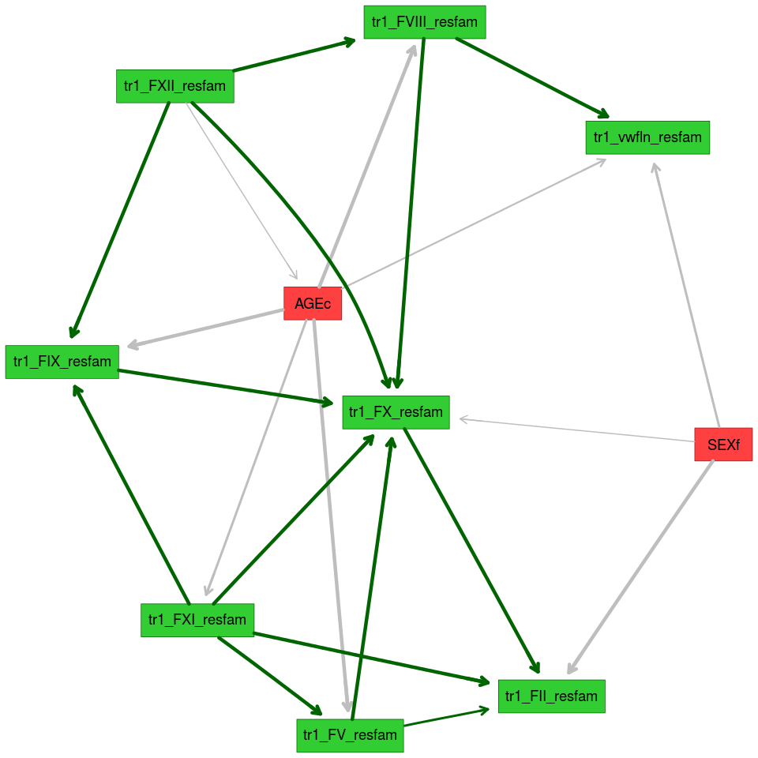

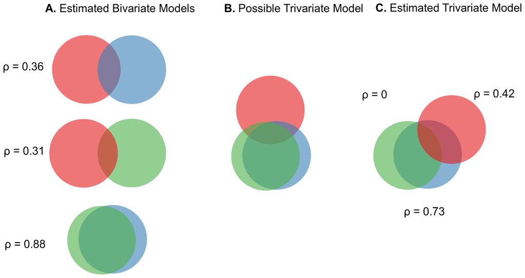

References

Glahn, David C, Jack W Kent, Emma Sprooten, Vincent P Diego, Anderson M Winkler, Joanne E Curran, D Reese McKay, et al. 2013. “Genetic basis of neurocognitive decline and reduced white-matter integrity in normal human brain aging.” *Proceedings of the National Academy of Sciences of the United States of America* 110 (47): 19006–11. doi:10.1073/pnas.1313735110.